# Interpretability Examples

First we load in the crabs data set. This contains physical measurements of several species of crabs collected at Fremantle, West Australia.

```r
library(MASS)
library(data.table)
library(ggplot2)
library(interpret)
library(Rforestry)
set.seed(491)
data <- MASS::crabs
levels(data$sex) <- list(Male = "M", Female = "F")
levels(data$sp) <- list(Orange = "O", Blue = "B")
colnames(data) <- c("Species","Sex","Index","Frontal Lobe",
                    "Rear Width", "Carapace Length","Carapace Width","Body Depth")
```

We can train a random forest to estimate the Carapace Width of the crabs based on the other features. In order to use the interpretability features, we must create a `Predictor` class for the estimator we want to interpret. This class standardizes the predictions, tracks the outcome feature, and stores the training data.

```r
# Get training data set
set.seed(491)
test_ind <- sample(1:nrow(data), nrow(data)%/%5)
train_reg <- data[-test_ind,]
test_reg <- data[test_ind,]
# Train a random forest on the data set
forest <- forestry(x=train_reg[,-which(names(train_reg)=="Carapace Width")],
                   y=train_reg[,which(names(train_reg)=="Carapace Width")])
# Create a predictor wrapper for the forest
# this allows us to use a standard wrapper for querying any
# trained estimator
forest_predictor <- Predictor$new(model = forest,
                                  data=train_reg,
                                  y="Carapace Width",
                                  task = "regression")
```

Once we have initialized a `Predictor` object for the forest, we can pass this to the `Interpretor` class. In the future, this will have several methods implemented as different options, but now it defaults to creating PDP functions + plots for the estimator. Examining the `Interpretor`, we can see the current method selected: “pdp”, the feature names, the training data indices, and the lists of pdp functions.

```r
forest_interpret <- Interpreter$new(predictor = forest_predictor)
print(forest_interpret)
```

```
<Interpreter>
  Public:
    clone: function (deep = FALSE)
    data.points: 17 59 105 8 18 51 157 37 102 44 119 131 107 75 7 148 60  ...
    features: Species Sex Index Frontal Lobe Rear Width Carapace Lengt ...
    functions.1d: list
    functions.2d: list
    initialize: function (predictor = NULL, samples = NULL, data.points = NULL,
    method: pdp
    predictor: Predictor, R6
```

The pdp functions are stored in two lists, one for 1-d pdp functions and one for 2-d pdp functions. For any feature, we can retrieve the pdp function by selecting the entry in the list with that feature name.

```r
# We can also access the Partial dependence functions themselves
one_feat <- train_reg$`Frontal Lobe`
preds_pdp <- forest_interpret$functions.1d$`Frontal Lobe`(one_feat)
print(preds_pdp)
```

```
  [1] 34.36860 34.48551 34.50897 34.52026 34.79546 35.05197 35.05961 35.14318 35.51752 35.51752 35.52848 35.57944
 [13] 35.59720 35.70633 35.92302 36.11112 36.49024 36.49024 36.81448 36.84015 37.38485 37.48175 37.48175 37.49159
 [25] 37.52369 37.63488 37.68741 37.70201 37.71721 37.71721 37.73722 37.78509 37.81327 37.82322 37.94573 38.64446
 [37] 38.64446 38.68524 38.69586 38.69586 38.85968 34.34733 34.43668 34.43415 34.49574 34.52026 34.52577 34.54176
 [49] 34.73539 34.79863 35.03430 35.05197 35.05774 35.07729 35.29752 35.51752 35.51752 35.55856 35.57944 35.58594
 [61] 35.60092 35.70633 36.14935 36.33410 36.49024 36.57739 36.57739 36.81448 36.83291 36.84015 36.85458 36.86451
 [73] 36.90101 37.33936 37.49159 37.55213 37.74706 37.75287 38.51101 34.43415 34.52764 34.57663 35.14151 35.32614
 [85] 35.58594 35.60092 35.64738 35.71425 35.71666 35.71666 35.72545 35.72545 35.72545 36.11112 36.14935 36.57739
 [97] 36.57739 36.84015 36.90101 37.49159 37.52369 37.71721 37.74706 37.75287 37.75287 37.80035 37.81327 37.82322
[109] 37.82686 37.84055 37.94573 37.94573 38.64979 38.66208 38.69879 38.75084 38.85695 38.89987 38.91129 38.98166
[121] 38.98821 34.57663 34.84945 35.14151 35.29752 35.71425 35.92302 36.14935 36.33410 36.49024 36.86451 36.86451
[133] 36.90101 37.49159 37.64310 37.75287 37.75287 37.76272 37.82322 37.82322 37.82715 37.83290 37.83290 37.84055
[145] 37.94573 37.99513 38.06408 38.06408 38.69801 38.67715 38.66208 38.66190 38.68033 38.69879 38.73422 38.85968
[157] 38.85954 38.89987 38.92250 38.98821
```

In order to use these pdp functions to create plots, we can use the `Plotter` function. This allows us to make standard pdp plots as well as conditional pdp plots with two variables. Here we show a single variable pdp plot and two conditional pdp plots with second categorical variables.

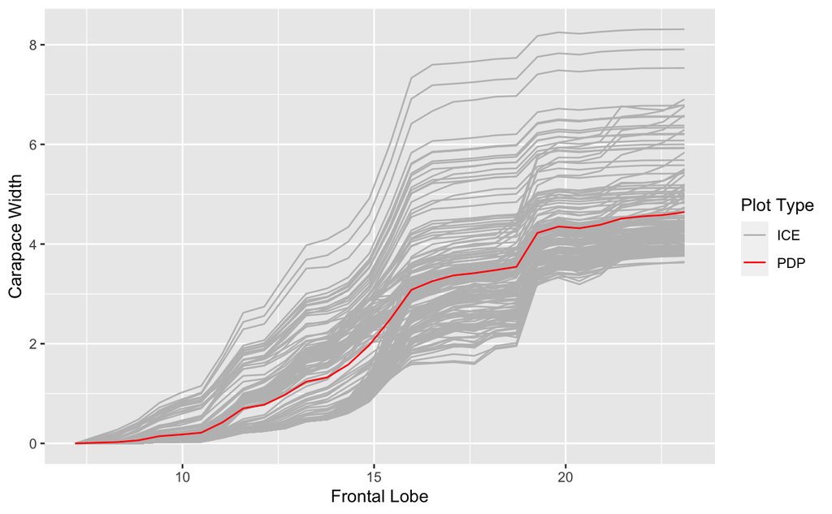

```r
# check plotter wrapper
forest_plot <- Plotter$new(forest_interpret, features = c("Frontal Lobe"),
                          features.2d = data.frame(col1 = c("Frontal Lobe", "Frontal Lobe", "Frontal Lobe"),
                                                   col2 = c("Species", "Sex", "Rear Width")))
plots <- plot(forest_plot)
plots[[1]]
```

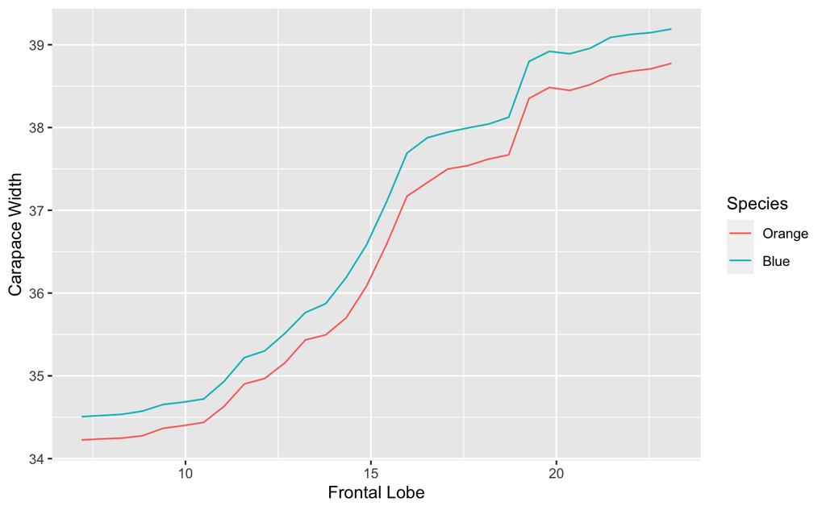

```r
plots[[2]]
```

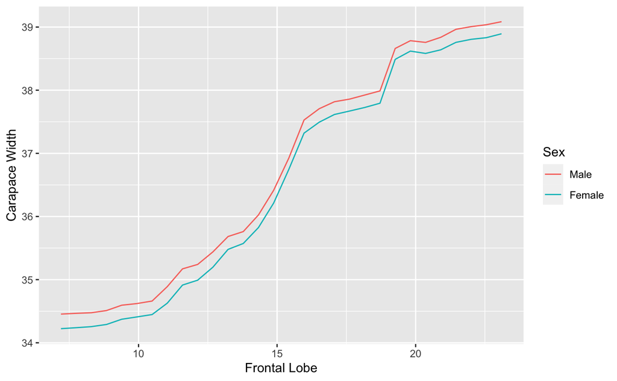

```r
plots[[3]]
```

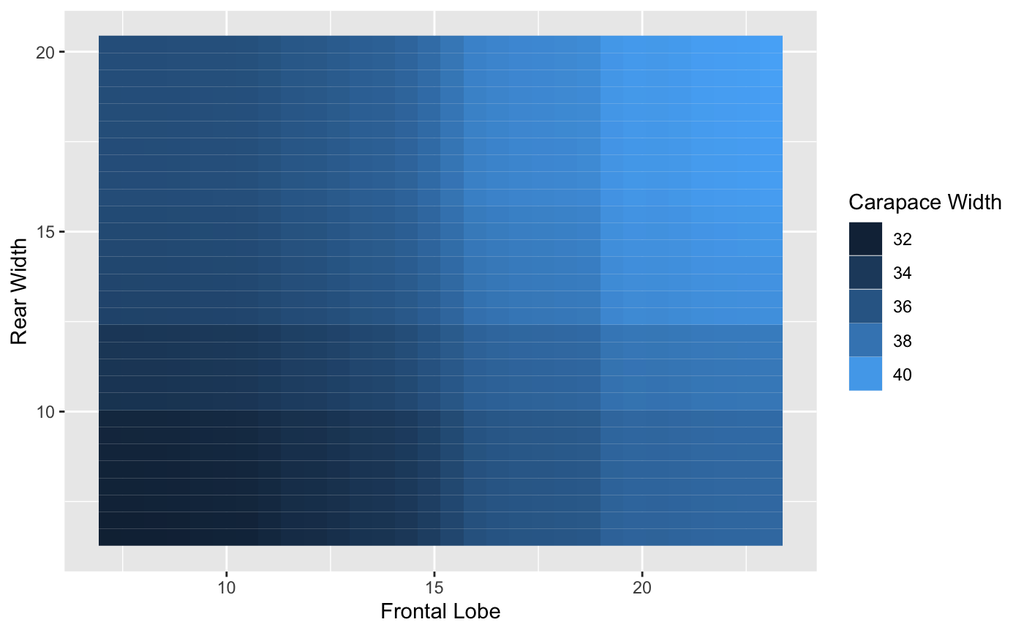

```r
plots[[4]]
```

We can also adjust where the plots are centered at for each feature, and what grid of points are used in the evaluations that create the plots.

```r
# Set center and grid points for the plots
forest_plot$center.at$`Frontal Lobe`
```

```
[1] 7.2
```

```r
forest_plot$grid.points$`Frontal Lobe`
```

```
 [1]  7.200000  7.748276  8.296552  8.844828  9.393103  9.941379 10.489655 11.037931 11.586207 12.134483 12.682759
[12] 13.231034 13.779310 14.327586 14.875862 15.424138 15.972414 16.520690 17.068966 17.617241 18.165517 18.713793
[23] 19.262069 19.810345 20.358621 20.906897 21.455172 22.003448 22.551724 23.100000
```

```r
# We can reset where we center the plot
set.center.at(forest_plot, "Frontal Lobe", 2) # for numeric
forest_plot$center.at$`Frontal Lobe`
```

```
[1] 2
```